## Fragments

In the 1960s there was massive and widespread *system-level* political contention in many countries around the world.[^1]

Beginning in the 1970s, there was then an equally widespread decrease in system-level political contention which was, in long-term historical perspective, remarkably rapid and comprehensive. Crucially, this pacification of system-level contention occurred at the behavioral *and* ideational level. That is, politically contentious behavior at the system-level (for instance, general strikes, assassinations, riots, guerrilla warfare, revolutions, etc.) saw a precipitous decrease, but at the same time, the content and intensity of public culture became strikingly less contentious with respect to institutions. This is simply another way to summarize a large set of well-known observations, many of which will be explored in the pages to come, including the rise of mass consumerism (in commerce), the decline of unions and rise of business-speak (in the workplace), the decline of artistic counterculture and the rise of commercialized and individualized replacements such as ``DIY" culture, individualised forms of political radicalism (second wave to third wave feminism, social anarchism to lifestyle anarchism). What all of these movements have in common is that they represent behavioral and ideational shifts away from collective opposition to institutions and toward individual-level struggle within institutions which are taken for granted.

To document and explain this surprisingly under-reported empirical puzzle, I will make a series of arguments that focus on the nature of information in politics. These arguments lead to the following argument, which will of course require some effort to adequately unpack. I will argue that the information revolution led to an uneven but worldwide shift in ethical and behavioral orientations. By increasing the payoffs to instrumental rationality (exploitative human action based on maximizing efficiency of means) relative to substantial rationality (honest/dialectical/cooperative action driven by ultimate goals), individuals and organizations with exploitative ethics were significantly more empowered by the information revolution than those with cooperative ethics. In a process of incentivized learning, there was a massive defection from substantial rationality (and system-level political contention against institutions and for human liberation from the domination of institutions) to instrumental rationality (individual-level adjustment to institutions).

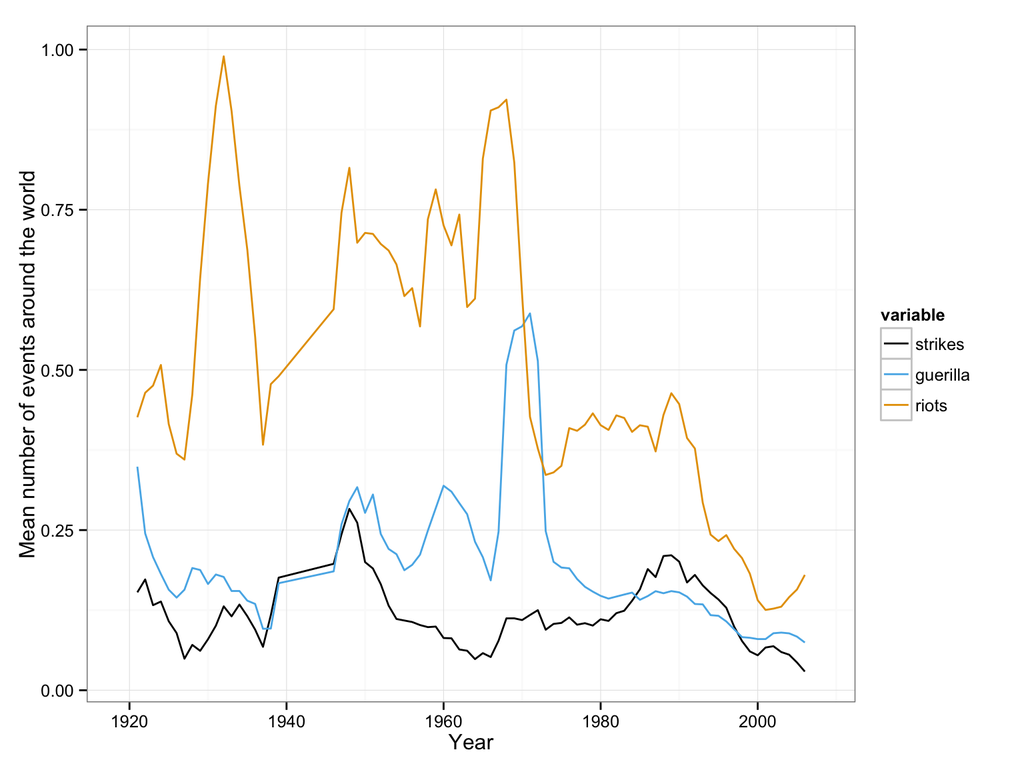

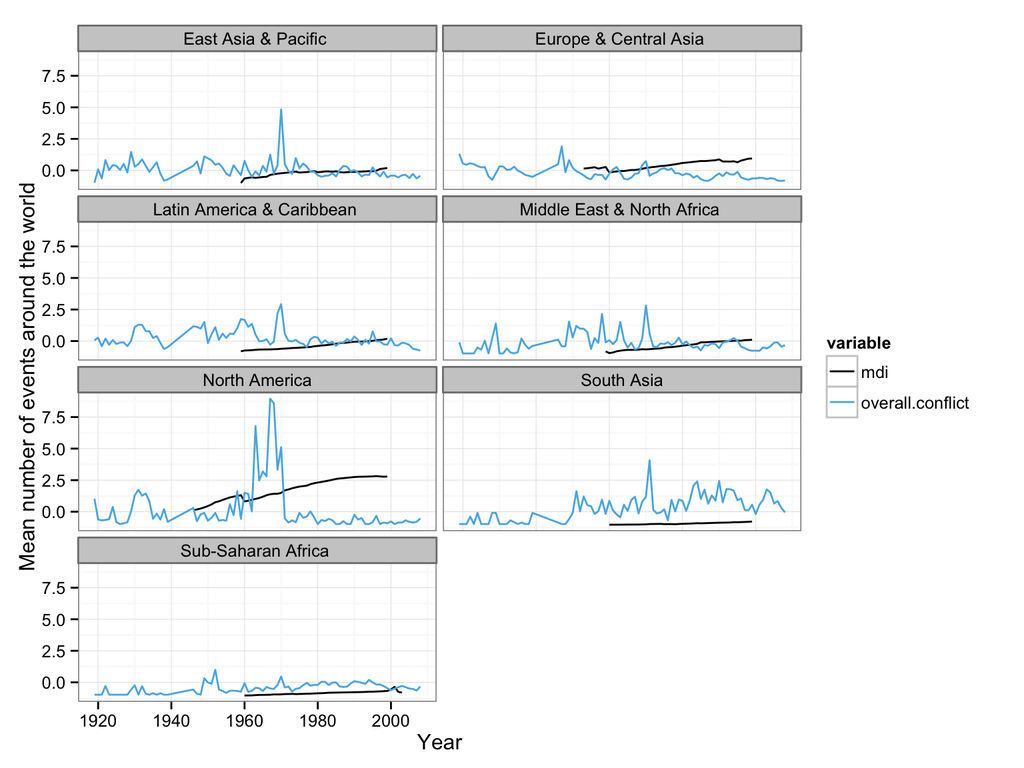

The conventional wisdom for explaining this shift is that the contention of the mid-century was directed mostly toward colonial oppressors and authoritarian regimes, so that all of this militant contention dissipated simply because decolonization and democratization gave people what they wanted: freedom from colonialism and democracy. This is, of course, one way to read the history. But objectively, there is a huge problem for this conventional wisdom, which mainstream social scientists will not even touch, and indeed they *cannot* even touch it without revealing the bad faith behind almost all of their concepts. That objective problem is that decolonization on the whole did not give way to robust national independence for the formerly colonized peoples and democratization on the whole did not lead to democratic governments. All of the most powerful genuine democratic (typically socialist) surges were aggressively thwarted by conservative interests, often with some amount of cooperation from the United States and its partner countries. To name the most well-known cases: Mossadegh in Iran 1953, Árbenz in Guatemala 1954, Qasim in Iraq 1960-63, Lumumba in Congo 1961, Ngô Đình Diệm in Vietnam 1963, Allende in Chile 1970-1973, the Communist party in Afghanistan 1979-89, Sandanista in Nicaragua 1981-1990.)

In this light, the processes of decolonization and “democratization” rarely if ever led to substantially new and improved national periods of political-economic satisfaction. While there were no doubt significant changes in the institutional distribution of powers within and across countries, it really just doesn’t objectively play out as a shift from oppression to liberation; rather it really seems much more like the shift from one type of equilibrium to a very different kind of equilibrium, but one which continues to be characterized by massive political and economic oppression.

## Instrumental and Substantial Communication

There’s a crucial distinction, emphasized in particular by the Frankfurt School, between instrumental and substantive rationality. Broadly, instrumental rationality is that type of rationality concerned with calculating means to ends and substantive rationality is that type of rationality concerned with understanding the whole (means and ends). Instrumental rationality is concerned with strategy, calculating how to get *anywhere* the most efficiently, whereas substantive rationality is concerned with trying to figure out where one should go in general.

The distinction emerges over and over again in politics.

- the personal integrity of anarchism vs the instrumentalism of marxism
- ethos and elan vs a separate realm of strategy (that is, even activists notion of “goal, strategy, tactics” begs the key questions of how to live and therefore simply skips precisely to the battlefield in which it has already been crushed)

Because the public sphere has been so completely subordinated to instrumentalism—the only speech which is even sensible is that which meets some minimal threshold of self-interest, because nothing else is credible—the most preliminary efforts to establish a genuinely kind and loving contact with another human being are basically impossible—let alone build radical ties or a social movement! This extraordinary change, and undeniable *decay* in communications has never before been fully identified, let alone explained. This also explains why today all currently existing social movements are completely unable to build anything which can even pretends to challenge the dominant institutions.

Instrumental communication is a means to some end which is not communicated in the message. That which seeks to make the receiver do something at the cost of some transparency (treats them as a means to an end; the first goal is to achieve something for the speaker’s interests).

non-instrumental communication is an end in itself which the communicator says for no reason other than whatever satisfactions are brought by saying it. Or importantly, if there is a larger end to speaking it, this is included in the message. Non-instrumental communication therefore treats the receiver as an end in themself, because the only instrumental value the communication can bring is through the autonomous action of the receiver after learning transparently the contents of the message.

They are perhaps never fully one or the other, but the argument here does not require absolute purity. It is enough to mark out objectively the consistent markers of the one and other. There has always been a conflict between instrumental communication and non-instrumental (let’s call it sincere) communication. Typically, historically, instrumental communication is the communication of the relatively powerful and sincere communication is the communication of the powerless; additionally, instrumental communication is the communication of the powerful as well as the powerless in spaces and times relatively characterized by power struggle (in a job interview, for instance, where someone is obviously and consciously involved in a competition to win the means to sustain one’s life), whereas sincere communication is the communication of all people in spaces and times relatively insulated from power struggles (with loved ones, for instance). While these types of communication have always co-existed, for most of human history they have been in equilibrium. Before the printing press, ruling elites in any particular society did not have an advantage in exercising instrumental communication over their subjects. They had symbolic machinery no doubt, but the subjects had what since time immemorial has been the most powerful communicative structure: being socially embeded among others in a concretely shared, if rarely equal, co-production of life. Indeed, to this day, it is known very well that one’s attitudes and behaviors are most crucially shaped by one’s “primary group,” precisely the individuals by whom one is surrounded on a day-to-day basis. Thus, the instrumental communications of the powerful have always been held in check by structures within which sincere communication prevailed. The lies of kings might have been obeyed because the balance of power forced subjects to accept them, but the history of human society shows amply that wherever domination prevails there also prevails the wisdom of the relatively weak who, sometimes laughing and sometimes crying and sometimes in silent gestures, always ultimately are the only bulwark which refutes the self-interested communications of the dominant.

However, since the industrial revolution, profound changes have occurred in this communicative balance of power.

In periods where the ability for a particular source to reach many people increases, there is always a sudden appearance of revolutionary political communication and revolutionary political upheaval. But after this opening, that which was so powerful for the forces of sincerity is exploited for instrumental purposes. While anyone can pursue their instrumental purposes after a sudden increase in the ability to reach people, almost by definition the most powerful will be able to spread their instrumental communications more widely than the less powerful.

(always quicker to the punch precisely because that which is sincere and organic is always waiting to explode, whereas that which strategically manipulates can only respond, hence we call this “reactionary”.)

#### 1820-1875 first upturn of globalization

telegraph, newspapers, amateur radio first international, revolutionary upsurges, Fanelli goes to Spain

#### 1875-1914 down turn of globalization

recuperations within the left, state-corporate control of radio, second international, anarchist terrorism as last gasping breathe. watering down of “democracy” as republicanism in 1875. ww1 as corporate-state lockdown. bolshevism.

#### 1949-1975 upturn of second globalization (without people)

trade, mass media internationally, anti-colonial war, information revolution about 1950.

#### 1975-1991 downturn of second globalization (without people)

neoliberalism, mass media solidification, trade and investment integration, collapse of soviet instrumentalism, mass evactuation of left sincerity in favor of left instrumentalism within capitalism.

#### 1994-2011 upturn of the networked world

zapatistas up to arab spring and occupy, flowerings of sincerity.

#### 2011-Today downturn of the networked world, the pacified world

capitalism as mainstream ideology of most people rich and poor, left and right. the main ideological cleavage is between ruthless instrumentalism and humane instrumentalism, but the pole of sincere, substantive ethical and political truth opposed to instrumentalism has been vanquished from most of the globe. the internet.

### How Instrumental Rationality Favors the Right and Inhibits the Left

The problem of most left political thought and practice since time immemorial is that, because they are generated precisely by exploitative institutional arrangements, the only left messages which receive recognition within such cultures are those which respond to the material needs of the exploited. This is perfectly understandable, because the material needs which sustain life are both ethically and practically prior to any possible social movement on other grounds. This is why normatively lofty or aesthetically-driven currents of leftist political thought and practice are always mocked in every period: when some people are starving, rhetorical flights of any sort do *seem* to reflect mistaken priorities. Thus it is that mature and decent leftists always tend to discipline the younger more “idealistic” leftists into calming their normative and rhetorical passions in favor of the hard work of getting material gains for the most exploited people. While this is perfectly understandable and quite natural to sympathize with, there is an extraordinary problem with this tendency. Specifically, it grants to the exploitative institutional arrangements their most crucial ethical and epistemological assumption: instrumental rationality. It is necessary for the exploited to practice the instrumental rationality required for survival, but the problem is that because of this need, the left capitulates *in general* to instrumental rationality as the proper analytical orientation to social and political struggle. Anything which opposes instrumental rationality is, to the committed and *rational* leftist, a prodigal self-indulgence of an immature and “privileged” soul uneducated in the history of the Practical Left.

Nevermind that the history of the Practical Left is a history of betrayal, capitulation, and ultimately, complete failure—given that domination and exploitation not only continue to exist but in the institutions of global capitalism institutionalized more powerfully than ever before in the history of humanity.

## skill-biased technological change

One reason is that improvements in information are a type of “skill-biased technological change” in which the relatively more educated see their power increase more than the less educated, but this is not unique to information technology. The crucial and unique implication is that, at least within market societies, advancements in information-processing bias all social communication toward status quo assumptions. Despite the widespread belief that new information technologies enhance democracy and cooperation, I argue that in the long-run, improvements in information-processing increase the profitability of instrumental or exploitative communication relative to cooperative or goal-driven communication. This is because those most invested in the status quo will use advancements in information-processing to advance themselves within the status quo rather than change the status quo as such; this forces those who would otherwise seek to change the status quo to speak and behave in agreement with the assumptions of the status quo in order to survive. While such a dynamic emerges for many types of technological innovation, only improvements in information-processing have such unique and far-reaching negative externalities on the public sphere because, while skill-biased technological change in industry might lead some workers to earn more in the factor, skill-biased change in information-processing leads some individuals to earn more from everyone in their life in general. For these reasons, the information revolution sparked a process in which all communication around the world is increasingly only instrumental communication, and the substantial communication required for individuals and communities to challenge elites is increasingly evacuated. This accounts for why, today, nearly all dominant political categories ring hollow, diverse types of social trust are depleted, and militant political resistance to the status quo has been pacified and erased from memory in the short span of about thirty years.

### The conservatism of everyday speech

(Rephrase because this is in pamphlet.)

Everyday words do not communicate, they are much better understood oppositely: they are blockages of communication, evolved to divide, channel, distort, and otherwise institutionalize the human community to increase utility of the most powerful groups. It is one of the largest and most powerful set of mechanisms for maintaining capitalism because they are the million little signposts which at every moment point to people which roads pay. At every fork in our road, at those specific moments when we do have the resources to choose good or evil, words always send us toward capitalism because words (logos) at best are merely true (a car which doesn’t come with an engine, let alone fuel). Logic and reason are motion-neutral, “disinterested” objective analysis cannot tell anyone what to value, as only subjective desire and commitment can propel and direct a person’s projects — but in a dynamic system *defined by* the instrumental exploitation of humans, then disinterested logos and ratio is exploitation. Strong logical reasoning is always paid because good thinking always strays and is always at risk of overthrowing the status quo. Words provide the service of absorbing a society’s cognitive capacities into channels which prevent volatile shifts of group movement. And we are simply paid to use those words which absorb or mystify or deflect human desire into a desire for capitalism. We earn nothing if we use words which fail to channel human desire into exploitation, and finally we are punished to the degree our words challenge or inconvenience powerful actors.

### Economic premium to computational thinking

A huge problem with the information age is that because computational skills are rewarded disproportionately, and the top calculator minds quickly become privileged by the status quo, what comes to be counted and calculated tends to be motivated by a blithe confidence and satisfaction with the institutions of the status quo.

### Principled Contentious Action

We might call “principled contentious action” anti-institutional or anti-systemic political behaviors grounded in truth claims this is what has been pacified there are still some contentious uprisings and there are still people making truth claims but these have been separated, and that is the crucial mystification which defines our world. but zola was also very strategic, how is that different than today? being strategic in a principled campaign is different than today, which is generating principles to serve strategic ends. in the former, ends are sincere but the means are strategic. in the latter, means are sincere but the ends are dishonest. zola took radical strategic action in pursuit of forcing truth and justice, even if he did it strategically; non-profit organizations use claims of truth and justice as a vehicle for strategically promoting certain groups.

### Understanding the nature of commercial bias

mass media have not programmed people to think or act in a certain way, they simply disconnect popular *resistance* from the reality of political affairs

the mechanism through which they do this is simply giving people what they want to hear and see. this is acknowledged by every media scholar to be a fundamental fact of commercial media. but it’s effect is to create “noise” in the democratic mechanism whereby people positively or negatively to political affairs. Because by definition people are receiving what they want, the bias is not left or right but rather media are biased in favor of system-level dynamics and against within-system dynamics. This is how we can account for the perplexity that people often think the media is TOO critical of politicians AND that it is not critical enough.

but it’s not just noise in the sense of random noise, it is by definition reinforcing of what they already think and feel and believe. this sounds like it might push radicals to be more radical and conservatives to be more conservative but this is wrong. why? because of a fundamental assymetry between left and right, which spatial models of politics fail to account for.

the right is whatever political reality is. the left is the desire to change the status quo to bring it more in line with justice. the right is that the status quo is justice and the change they promote is to stop those efforts.

thus, commercial media is inherently conservative. it has the effect of reinforcing the status quo (the right) by giving people what they already want, rather than connecting them to whatever might be wrong with the world, thus pacifying the crucial inputs which historically lead people into contention with dominant powers.

what exactly has been pacified? principled contentious action. there’s still contention because there’s plenty of ways to be contentious roughly in support of the status quo. what has been foreclosed is resistance to the status quo based on ethical or spiritual commitments. instrumental contentious action persists, because instrumental contentious action is the dominant mode of life sanctioned and encouraged by the status quo.

principled contentious action is not left or right. like marxists didn’t support dreyfus, and some bourgeois political moderates did. if there is anyone who embodies it, it’s the radical public intellectual of theory and action.

### Keynes and the False Promise of Taming Capitalism

1. Someday we will look back on the notion of markets as we today look back on the witch trials: as a mass-delusional catastrophe in the ethical history of the world.
2. It is not that markets don’t exist, it is not even that markets don’t work. The problem is precisely that they do work.
3. The problem with Keynseianism is that by arguing that markets don’t always work, it maintained the assumption of instrumentalism.
4. Keynes severely interrupted the revolutionary tendency, not because he was wrong, but because he was right.
5. Leftists in general pacify themselves with moralism. It prefers to feel ethically and morally righteous over getting things right.
6. Getting it “right” requires us to admit that conservatism is “right,” it is not *false*.
7. To be radical is to choose to get it wrong with respect to the status quo, because one sees the status quo as wrong.
8. Today our “left” is so oriented toward being true within the status quo that it is unable to be anything other than the status quo.
9. It has been forced to seek truth within the status quo because mass media significantly increased the gains to being true within the status quo relative to saying the status quo is wrong. Globalization has multiplied this effect for the same reason. And since the late 1960s there’s been a remarkable though essentially invisible ethical re-orientation toward consistency with exploitation.

## Sketch of a general model (a distributive theory of information technology)

As informational efficiency rises, all social actors are empowered to the degree their work involves manipulating information. This is why the 1950s and 1960s saw many relative improvements in the lives of so many actors in the United States: executives of many stripes and perhaps most interestingly in the advertising and marketing sectors (“Mad Men”), consumers (the golden age of suburban idyll), and social reformers (60s radicalism and minority movements) were all empowered to some degree by the new informational powers.

But it also increases the short-term payoffs of manipulation relative to cooperation. Basically, increased information powers have the structure of a prisoner’s dilemma. Consider a new information power which can be used to either cooperate or manipulate, a radio for instance. If two people agree to use the radio to increase their cooperation by telling each other truths, they each face what we might call a vulnerability cost but gain what we might call a solidarity value. However, if one of them promises to tell the truth but actually lies about their own type, they pay zero vulnerability cost while still gaining the other person’s loyalty. The dominant strategy is to present a false type, and thus it is that in the long-run every advancement in information power actually incentivizes manipulative falsity.

The period from 1947 to 1973 was essentially the first stage of learning process, where various strategies for maneuvering in the digital world are experimented with. Cooperators cooperated more powerfully (the extraordinary potency of late 1960s radicalism), but manipulators also manipulated more powerfully, and the beginning of the 1970s was just the point at which the remaining cooperators defected in the face of a seemingly unstoppable reality of manipulation as destiny. Indeed, the late 60’s in particular is a last gasping breathe against instrumentality, and the 1970s marks its defeat by instrumental reason and begins a global ethical race to the bottom, where the left is sucked into a huge global vacuum, pulled either into the orbit of neoliberalism or mystified postures of protest merely bought and sold on the market. Hence all the radicals who gave up the radical struggle and opted for status quo media manipulation (consider the remarkable example of the Latin American revolutionary who laid down arms and went to work for a global PR firm, I have to find the citation for this…) or revolutionary media manipulation (even left-wing terrorism is only a manipulative propaganda of the deed).

The real casualty on both sides of the political divide was the truth and the radicalism and solidarity unique to human honesty.

One vector of this contention is played out in the rise of marketing understood broadly as the manipulation of human beings for earning profit, including the evolution of the marketing individual. This becomes scientific and massive for the first time ever, it’s scientificity is evident not only in elite practices such as quantitative marketing research but even in the most horrid and peculiar subcultures such as that of male “pick-up artists” who try to develop a vulgar science of manipulating women.

Another vector of this contention is played out in the organization of production processes. The rationalization of economic production as well as political (bureucratic or legal or military or “policy”) production.

But these vectors are really only relatively specific instances of engineering “operations,” a generic term in computer, engineering, and management sciences for any process of manipulating inputs to generate certain outputs.

### The Connection Between Media and Globalisation

The crucial connection of media and globalisation is this: as media increased the reach of any particular message (beginning within the nation state and then beyond it), this radically increased the payoffs to speaking consistently with the status quo. When the ability to speak globally occurred, this amplified it. At the same time, the same thing that made this communication possible (the digital revolution) also amplified the political and economic premium to education/skills.

When the amount of people any one person could reach was very small, it was worth it to resist status quo temptations and speak against the status quo. First of all because capitulating to the status quo did not get you much, and second because others who suffered under the status quo were unlikely to have much emotional investment in it (or at least there was no reason to believe they did, a crucial point regarding the logic of mass communications).

But as the potential reach of a status quo platform increased, this incentivized leftists to drop the radical discourse and trade it in for a hugely widespread but overall small positive effect rather than fight for system change. First because the payoff of a moderate message increased (you reach more people) but second because of the increasing belief that everyone else supports supports the status quo (because everyone else is getting pro-status quo messages).

[^1]: By *system-level political contention* I simply mean public political speech and behavior which challenged the distribution of power and resources at the level of institutions. By institution I only have in mind a basic sociological definition such as any shared understandings, backed by force or not, which effectively structure the behavior of individual agents. In this sense I understand a political or economic *system* to be simply a set of institutions.